# DanishAgriculture

Lasse Horsøe Østergaard & Gustav Lynggaard Vinther

28 October, 2023

# Final Project: The Development of Danish Agriculture seen through data

# Library & loading packages

First we load the packages needed for our work

```r
library(tidyverse)
```

```r
library(ggplot2)
library(dplyr)
library(hrbrthemes)
library(tidyr)
library(gganimate)
```

# Loading Data

Afterwards we load the data from the data-folder, using read_csv() and assigning it as objects

```r
DrivhusgasBrancher <- read_csv("data/CleanCsv/drivhusgas_udledning_branche_tid_clean.csv")
LandbrugRegnskab100 <- read_csv("data/CleanCsv/landbrug_regnskab_100_clean.csv")
LandbrugDrivhusgasser <- read_csv("data/CleanCsv/landbrug_udledning_drivhusgasser_clean.csv")
LandbrugbedrifterAreal <- read_csv("data/CleanCsv/landbrugbedrifter_dyrket_areal _1984-2022_clean.csv")
BruttoværditilvækstBrancher <- read_csv("data/CleanCsv/NABP10_bruttoværditilvækst_flere_brancher_clean.csv")
BeskæftigelseBrancher <- read_csv("data/CleanCsv/NKBB10_Beskæftigelse_brancher_1966-2022_clean.csv")
```

# Visualisation and analysis

Now we move on to making the visualization with our data

## Danish Agriculture: areal and number of agricultural holdings: transforming the data

Firstly, we will look at the data and see if it needs som data-wrangling

```r
head(LandbrugbedrifterAreal)
```

```
## # A tibble: 6 × 4
##      år bedrifter_antal samlet_dyrket_areal_ha dansk_landareal_2023_ha
##   <dbl>           <dbl>                  <dbl>                   <dbl>
## 1  1984           95346                2854773                 4295200
## 2  1986           89659                2818910                 4295200
## 3  1988           84093                2786603                 4295200
## 4  1989           81267                2774128                 4295200
## 5  1990           79338                2788276                 4295200
## 6  1991           77197                2769657                 4295200
```

It appears we have to make some changes.

In order to make a visualization of this data, we create a coloumn to show the agricultures part of the danish land areal. To do this, we use the “dansk_landareal_2023_ha”, which is the total Danish land area in 2023 in hectares. We do this to get a visualization of the percentage of the agriculture’s part of Denmark. We use mutate() to create a new column called “landbrug_andel_af_DKAreal”

```r
LandbrugArealAndelPct <- LandbrugbedrifterAreal %>%
  mutate(landbrug_andel_af_DKAreal=(samlet_dyrket_areal_ha/dansk_landareal_2023_ha)*100)
```

Let us take a look at the data

```r
head(LandbrugArealAndelPct)
```

```
## # A tibble: 6 × 5
##      år bedrifter_antal samlet_dyrket_areal_ha dansk_landareal_2023_ha
##   <dbl>           <dbl>                  <dbl>                   <dbl>
## 1  1984           95346                2854773                 4295200
## 2  1986           89659                2818910                 4295200
## 3  1988           84093                2786603                 4295200
## 4  1989           81267                2774128                 4295200
## 5  1990           79338                2788276                 4295200
## 6  1991           77197                2769657                 4295200
## # ℹ 1 more variable: landbrug_andel_af_DKAreal <dbl>
```

This will allow us to make a visualization of the percentage of cultivated land areal in Denmark

## Danish Agriculture: areal and number of agricultural holdings: visualization

Now the data is ready for making a visualization

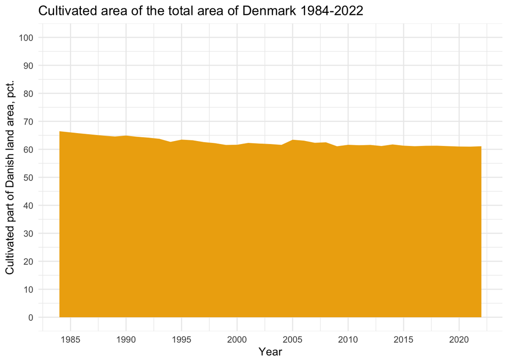

```r
LandbrugArealAndelPct %>%
  ggplot(aes(x=år, y=landbrug_andel_af_DKAreal))+
  geom_area(fill="darkgoldenrod2")+
  scale_y_continuous(limits=c(0, 100), breaks = scales::pretty_breaks(n = 10))+
  scale_x_continuous(limits=c(1984, 2022), breaks = scales::pretty_breaks(n = 10))+
  labs(title = "Cultivated area of the total area of Denmark 1984-2022", x="Year", y= "Cultivated part of Danish land area, pct.")+
  theme_minimal()
```

### Agricultural holdings in Denmark

In the same period there is a big decrease in the number of agricultural holdings

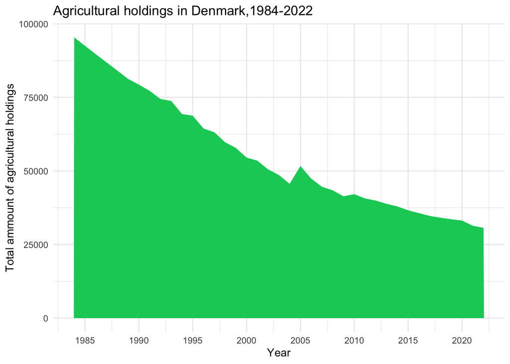

```r
LandbrugArealAndelPct %>%
  ggplot(aes(x=år, y=bedrifter_antal))+
  geom_area(fill="springgreen3")+
  scale_x_continuous(breaks = scales::pretty_breaks(n = 10))+
  labs(title = "Agricultural holdings in Denmark,1984-2022", x="Year", y= "Total ammount of agricultural holdings")+
  theme_minimal()
```

## Emission of greenhouse gases in Denmark divided by line of industry

The data for emission of greenhouse gasses in different lines of industries is ready to visualize. “Color = branche” is used to give every industry a different color

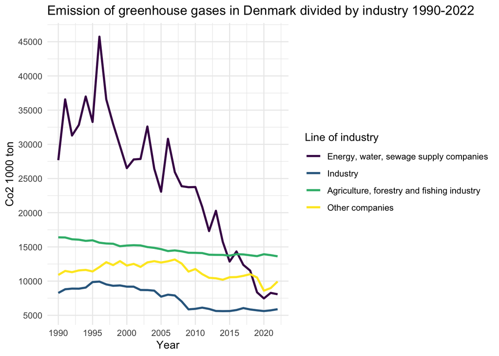

```r
DrivhusgasBrancher %>%
  ggplot(aes(x = år, y = Co2_1000ton, color = branche)) +
  geom_line(linewidth = 1) +
  scale_y_continuous(breaks = scales::pretty_breaks(n = 10)) +
  scale_x_continuous(breaks = scales::pretty_breaks(n = 10)) +
  scale_color_viridis_d(name = "Line of industry", labels = c("Energy, water, sewage supply companies", "Industry", "Agriculture, forestry and fishing industry", "Other companies"))+
  labs(title = "Emission of greenhouse gases in Denmark divided by industry 1990-2022", x = "Year", y = "Co2 1000 ton") +
  theme_minimal()
```

## Danish agriculture emission of different greenhouse gasses

The data of the development of Danish agriculture’s emission of different greenhouse gasses is visualization-ready as well. For this data we use geom_area() to showcase the different greenhouse gasses in comparison to each other.

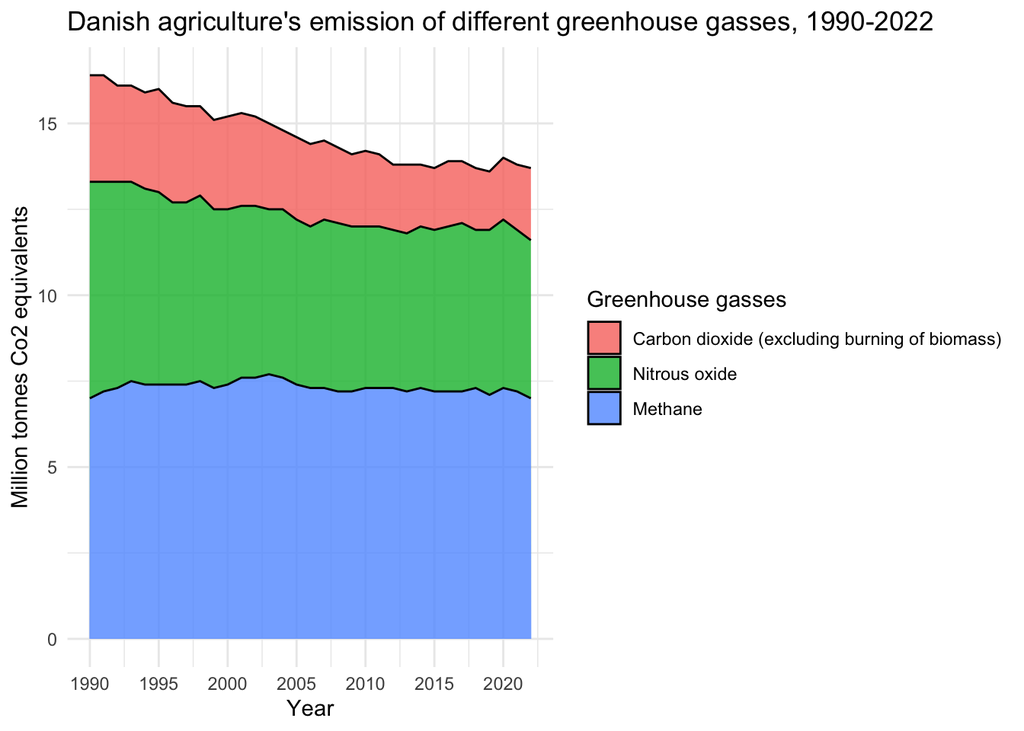

```r
LandbrugDrivhusgasser %>%
  ggplot(aes(fill=drivhusgas, x = år, y = `millioner_ton_Co2-ækvivalenter`))+
  geom_area(alpha=0.8,size=0.5, color= "black")+
  scale_x_continuous(breaks = scales::pretty_breaks(n = 10))+
  labs(title = "Danish agriculture's emission of different greenhouse gasses, 1990-2022", x="Year",y="Million tonnes Co2 equivalents")+
  scale_fill_discrete(name = "Greenhouse gasses", labels=c("Carbon dioxide (excluding burning of biomass)","Nitrous oxide","Methane"))+
  theme_minimal()
```

## Danish agriculture’s economical significance

Now we are going to make some animations to visualize some data, showing Danish agriculture’s economical impact on Danish economy.

### Gross value added and number of employees in different lines of industries: transforming the data

Firstly, we have to some data-wrangling to use it properly

```r
head(BruttoværditilvækstBrancher)
```

```
## # A tibble: 6 × 15
##      år offentlig_forvaltning…¹ landbrug_skovbrug_fi…² råstofindvinding industri
##   <dbl>                   <dbl>                  <dbl>            <dbl>    <dbl>
## 1  1966                   10707                   5513              240    14941
## 2  1967                   12513                   5228              243    16061
## 3  1968                   14537                   5474              265    17788
## 4  1969                   17072                   6499              281    19915
## 5  1970                   20404                   5897              285    21617
## 6  1971                   24175                   6460              278    23591
## # ℹ abbreviated names: ¹offentlig_forvaltning_og_service,
## #   ²landbrug_skovbrug_fiskeri
## # ℹ 10 more variables: forsyningsvirksomhed <dbl>, bygge_og_anlæg <dbl>,
## #   handel_og_transport_mv <dbl>, information_og_kommunikation <dbl>,
## #   finansiering_og_forsikring <dbl>,
## #   ejendomshandel_og_udlejning_af_erhvervsejendomme <dbl>, boliger <dbl>,
## #   erhvervsservice <dbl>, …
```

As seen above, the data is in a wide-data format. In order to make meaningful visualisations with the data “Bruttoværditilvækst” it has to be transformed into a tall data-format.

Therefore we use pivot_longer() to make a table with the different lines of industry under the column, “brancher” and their values under the column, “million_dkk”.

```r
BruttoværditilvækstBrancherTall <- BruttoværditilvækstBrancher %>%
  pivot_longer(cols= c("offentlig_forvaltning_og_service", "landbrug_skovbrug_fiskeri", "råstofindvinding", "industri", "forsyningsvirksomhed","bygge_og_anlæg","handel_og_transport_mv","information_og_kommunikation","finansiering_og_forsikring","ejendomshandel_og_udlejning_af_erhvervsejendomme", "boliger", "erhvervsservice","offentlig administration_undervisning_sundhed", "kultur_fritid_anden_service"), names_to = "brancher", values_to = "million_dkk")
```

Now, let’s check if the data has been transformed the way we wanted it to

```r
head(BruttoværditilvækstBrancherTall)
```

```
## # A tibble: 6 × 3
##      år brancher                         million_dkk
##   <dbl> <chr>                                  <dbl>
## 1  1966 offentlig_forvaltning_og_service       10707
## 2  1966 landbrug_skovbrug_fiskeri               5513
## 3  1966 råstofindvinding                         240
## 4  1966 industri                               14941
## 5  1966 forsyningsvirksomhed                    1418
## 6  1966 bygge_og_anlæg                          6928
```

It looks right.

Now we want to add employment rates in different lines of industry to the dataframe aswell, because the data contains the same industries in the same time period.

The process is the same as before, using pivot_longer() to put the different lines of industries under the column “brancher” and their values under the column “antal_beskæftigede

```r
BeskæftigelseBrancherTall <- BeskæftigelseBrancher %>%
  pivot_longer(cols= c("offentlig_forvaltning_og_service", "landbrug_skovbrug_fiskeri", "råstofindvinding", "industri", "forsyningsvirksomhed","bygge_og_anlæg","handel_og_transport_mv","information_og_kommunikation","finansiering_og_forsikring","ejendomshandel_og_udlejning_af_erhvervsejendomme", "boliger", "erhvervsservice","offentlig administration_undervisning_sundhed", "kultur_fritid_anden_service"), names_to = "brancher", values_to = "antal_beskæftigede")
```

Now we mutate() a new column in BeskæftigelseBrancherTall, using the column “million_dkk” in BruttoværditilvækstBrancherTall and assign it as a new dataframe, “BeskæftigelseBVT”

```r
BeskæftigelseBVT <- BeskæftigelseBrancherTall %>%
  mutate(Bruttotilvækst_MilDKK = BruttoværditilvækstBrancherTall$million_dkk)
```

Let us see if we have succeded in combining the two

```r
head(BeskæftigelseBVT)
```

```
## # A tibble: 6 × 4
##      år brancher                        antal_beskæftigede Bruttotilvækst_MilDKK
##   <dbl> <chr>                                        <dbl>                 <dbl>
## 1  1966 offentlig_forvaltning_og_servi…             268885                 10707
## 2  1966 landbrug_skovbrug_fiskeri                   298679                  5513
## 3  1966 råstofindvinding                              3231                   240
## 4  1966 industri                                    562182                 14941
## 5  1966 forsyningsvirksomhed                         14257                  1418
## 6  1966 bygge_og_anlæg                              221242                  6928
```

Now we have combined the two dataframes into one and should be able to move on with the animating

### Gross value added and number of employees in different lines of industries: animating

The function: transition_time(as.integer(år)), animates the geom_point() to change for every year Different scaling is done for aesthetic reasons The legend and the labels under are edited using: scale_color_viridis_d(). shadow_wake() is used to make small “tails” on each point to accentuate the movement of the different points.

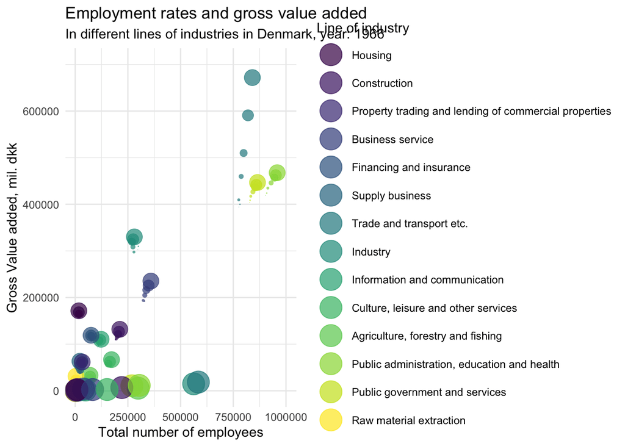

```r
options(scipen = 999)

BBVT_Animation <- BeskæftigelseBVT %>%
  ggplot(aes(x=antal_beskæftigede, y=Bruttotilvækst_MilDKK, color = brancher)) +
  geom_point(show.legend = TRUE, alpha = 0.7, size=8, )+
  scale_color_viridis_d(name = "Line of industry", labels = c("Housing","Construction","Property trading and lending of commercial properties","Business service","Financing and insurance","Supply business","Trade and transport etc.","Industry","Information and communication","Culture, leisure and other services","Agriculture, forestry and fishing","Public administration, education and health","Public government and services","Raw material extraction"))+
  scale_y_continuous(limits=c(240, 700000))+
  scale_x_continuous(limits=c(3231, 1000000))+
  scale_size(range=c(2,12))+
  transition_time(as.integer(år))+
  labs(title = "Employment rates and gross value added", subtitle = "In different lines of industries in Denmark, year: {frame_time}", x="Total number of employees", y="Gross Value added, mil. dkk")+
  shadow_wake(wake_length = 0.1, alpha = FALSE)+
  theme_minimal()

BBVT_Animation
```

### Focus on employment in Danish agriculture

```r
LandbrugBeskæftigelsePlot<- BeskæftigelseBrancher %>%
  ggplot(aes(x=år, y=landbrug_skovbrug_fiskeri))+
  geom_line(color="darkslateblue", linewidth= 2)+
  scale_y_continuous(breaks = scales::pretty_breaks(n = 10)) +
  scale_x_continuous(breaks = scales::pretty_breaks(n = 10)) +
  labs(title = "Danish agriculture employment", subtitle = "Total number of people employed, 1966-2022", x = "Year", y = "Total number of employees") +
  theme_minimal()
```

And now we animate:

```
## `geom_line()`: Each group consists of only one observation.
## ℹ Do you need to adjust the group aesthetic?
## `geom_line()`: Each group consists of only one observation.
## ℹ Do you need to adjust the group aesthetic?
```

[figure not shown]

```r
 LandbrugBeskæftigelsePlot + transition_reveal(år)
```